# SUMMARY REPORT for new IQWiG data (restricted to 2 studies)

Author

Saverio Fontana

Published

January 8, 2026

# 1 Data Overview

We are inspecting a total of **1165** meta-analysis. Those are all made up of 2 studies.

## 1.1 Sheet division

Here is an overview of how many meta-analyisis are there in each Excel sheet

```r
a <- df_estimates %>%
   group_by(sheet_name) %>%
   summarize(n_MA = n()/2)

a %>%
  gt() %>%
  #  Relabel Columns
  cols_label(
    sheet_name = md("**Data Sheet Name**"),
    n_MA = md("**Number of Meta-Analyses (N)**")
  )
```

| **Data Sheet Name** | **Number of Meta-Analyses (N)** |
| --- | --- |
| A_NB | 256 |
| D_NB | 54 |
| Dossiers | 475 |
| EVB | 100 |
| N_NB | 273 |
| S_NB | 7 |

## 1.2 Measure employed

This is an overview of the different measures employed over the file

```r
df_estimates %>%
  count(effect.measure, .drop = FALSE)  %>%
  mutate(n = n/2 ) %>%
   arrange(desc(n)) %>%
   gt() %>%
  # Relabel Columns
  cols_label(
    effect.measure = md("**How measures are reported**"),
    n = md("**Number**")
  )
```

| **How measures are reported** | **Number** |
| --- | --- |
| RR | 305 |
| OR | 302 |
| MD | 255 |
| SMD | 165 |
| HR | 123 |
| IDR | 8 |
| RD | 6 |
| ROM | 1 |

## 1.3 Data formatting

Another interesting fact was the way IQWIG reported the raw data. I classified them in 13 possible ways. This also show us which are the most common ways of reporting Meta Anslysis.

- **2x2 OR**: Binary outcome reported as a 2×2 event table (a,b,c,d); effect computed as log odds ratio from counts.
- **2x2 RR**: Binary outcome reported as a 2×2 event table; effect computed as log risk ratio from counts.
- **2x2 RD**: Binary outcome reported as a 2×2 event table; effect computed as risk difference from counts.
- **HR**: Study reports the hazard ratio (or log-HR) with its standard error directly.
- **direct OR**: Study reports the odds ratio (or log-OR) with its standard error directly.
- **direct RR**: Study reports the risk ratio (or log-RR) with its standard error directly.
- **direct RD**: Study reports the risk difference with its standard error directly.
- **ROM**: Study reports the ratio of means (typically on the log scale) with its standard error directly.
- **IDR**: Study reports the incidence density rate ratio (typically on the log scale) with its standard error directly.
- **direct SMD**: Study reports the standardized mean difference with its standard error directly.
- **direct MD**: Study reports the mean difference with its standard error directly.
- **MD pooled SD**: Continuous outcome: study reports mean difference (MD), pooled SD, and group sizes (n1, n2).
- **SMD from pooled**: Continuous outcome: study reports MD, pooled SD, and group sizes; SMD (Hedges’ g) is derived from these.
- **singular studies MD**: Continuous outcome: study reports group means and SDs (ȳ1, s1, n1; ȳ2, s2, n2); MD is computed.
- **singular studies SMD**: Continuous outcome: study reports SDs and group means; SMD is computed.

```r
df_estimates %>%
  count(data_report, .drop = FALSE)  %>%
   arrange(desc(n)) %>%
  mutate (n = n/2) %>%
   gt() %>%
  # Relabel Columns
  cols_label(
    data_report = md("**How data is reported**"),
    n = md("**Number**")
  )
```

| **How data is reported** | **Number** |
| --- | --- |
| 2x2_RR | 282 |
| 2x2_OR | 275 |
| singular_studies_MD | 170 |
| HR | 123 |
| singular_studies_SMD | 111 |
| direct_MD | 85 |
| SMD_from_pooled | 33 |
| direct_OR | 27 |
| direct_RR | 23 |
| direct_SMD | 21 |
| IDR | 8 |
| 2x2_RD | 6 |
| ROM | 1 |

# 2 Summary measures

This summary is computed using all the MA from above.

## 2.1 Width of the confidence intervals

For each method, we summarize the distribution of **CI widths** (upper − lower) across all two-study meta-analyses.

```r
widths <- extract_ma_metric(cis, "width")

# Calculate summary statistics
width_summary <- widths %>%
  group_by(method) %>%
  summarise(
    mean = mean(width, na.rm = TRUE),
    sd = sd(width, na.rm = TRUE),
    median = median(width, na.rm = TRUE),
    q25 = quantile(width, 0.25, na.rm = TRUE),
    q75 = quantile(width, 0.75, na.rm = TRUE),
    min = min(width, na.rm = TRUE),
    max = max(width, na.rm = TRUE),
    .groups = "drop"
  )


width_summary %>%
  gt() %>%
  tab_header(
    title = md("**Confidence Interval Widths**"),
  ) %>%
  cols_label(
    method = "Method",
    mean = "Mean",
    sd = "SD",
    median = "Median",
    q25 = "Q25",
    q75 = "Q75",
    min = "Min",
    max = "Max"
  ) %>%
  fmt_number(
    columns = c(mean, sd, median, q25, q75, min, max),
    decimals = 2
  ) %>%
  cols_align(
    align = "center",
    columns = -method
  ) %>%
  tab_style(
    style = cell_text(weight = "bold"),
    locations = cells_column_labels()
  ) %>%
  opt_stylize(style = 6, color = "blue")
```

**Confidence Interval Widths**

| Method | Mean | SD | Median | Q25 | Q75 | Min | Max |
| --- | --- | --- | --- | --- | --- | --- | --- |
| Edgington | 2.81 | 7.22 | 1.05 | 0.52 | 2.45 | 0.02 | 105.55 |
| Edgington (1/SE) | 2.64 | 6.76 | 0.97 | 0.50 | 2.26 | 0.02 | 102.56 |
| Edgington (1/SE^2) | 2.47 | 6.18 | 0.94 | 0.48 | 2.19 | 0.02 | 98.38 |
| Fixed effect | 2.16 | 5.07 | 0.86 | 0.45 | 1.93 | 0.02 | 59.35 |
| Hartung & Knapp | 19.70 | 56.18 | 6.71 | 3.47 | 16.35 | 0.11 | 876.08 |

### 2.1.1 Width by effect measure

Widths stratified by effect measure

```r
# Extract widths
widths <- extract_ma_metric(cis, "width")

# Calculate summary statistics stratified by effect.measure and method
width_summary <- widths %>%
  group_by(measure, method) %>%
  summarise(
    mean = mean(width),
    sd = sd(width),
    median = median(width),
    q25 = quantile(width, 0.25),
    q75 = quantile(width, 0.75),
    min = min(width),
    max = max(width),
    .groups = "drop"
  )

# Create table
width_summary %>%
  gt(groupname_col = "measure") %>%
  tab_header(
    title = md("**Confidence Interval Widths by Effect Measure and Method**"),
  ) %>%
  cols_label(
    method = "Method",
    mean = "Mean",
    sd = "SD",
    median = "Median",
    q25 = "Q25",
    q75 = "Q75",
    min = "Min",
    max = "Max"
  ) %>%
  fmt_number(
    columns = c(mean, sd, median, q25, q75, min, max),
    decimals = 2
  ) %>%
  cols_align(
    align = "center",
    columns = -method
  ) %>%
  tab_style(
    style = cell_text(weight = "bold"),
    locations = cells_column_labels()
  ) %>%
  opt_stylize(style = 6, color = "blue")
```

**Confidence Interval Widths by Effect Measure and Method**

| Method | Mean | SD | Median | Q25 | Q75 | Min | Max |
| --- | --- | --- | --- | --- | --- | --- | --- |
| HR |  |  |  |  |  |  |  |
| Edgington | 0.81 | 0.62 | 0.64 | 0.44 | 0.92 | 0.20 | 3.31 |
| Edgington (1/SE) | 0.78 | 0.60 | 0.59 | 0.41 | 0.90 | 0.12 | 3.31 |
| Edgington (1/SE^2) | 0.76 | 0.60 | 0.56 | 0.40 | 0.88 | 0.11 | 3.31 |
| Fixed effect | 0.73 | 0.60 | 0.56 | 0.37 | 0.86 | 0.12 | 3.35 |
| Hartung & Knapp | 5.30 | 4.03 | 3.97 | 2.86 | 6.01 | 0.75 | 21.73 |
| IDR |  |  |  |  |  |  |  |
| Edgington | 1.23 | 1.24 | 0.59 | 0.46 | 1.65 | 0.31 | 3.85 |
| Edgington (1/SE) | 1.09 | 1.26 | 0.57 | 0.42 | 1.12 | 0.16 | 3.83 |
| Edgington (1/SE^2) | 1.06 | 1.25 | 0.55 | 0.40 | 1.08 | 0.15 | 3.80 |
| Fixed effect | 0.85 | 0.91 | 0.51 | 0.29 | 0.98 | 0.15 | 2.82 |
| Hartung & Knapp | 7.94 | 9.53 | 4.40 | 2.50 | 8.13 | 1.00 | 28.61 |
| MD |  |  |  |  |  |  |  |
| Edgington | 7.90 | 14.15 | 3.11 | 0.55 | 7.18 | 0.02 | 105.55 |
| Edgington (1/SE) | 7.43 | 13.22 | 2.92 | 0.47 | 6.73 | 0.02 | 102.56 |
| Edgington (1/SE^2) | 6.89 | 12.05 | 2.36 | 0.42 | 6.58 | 0.02 | 98.38 |
| Fixed effect | 5.85 | 9.85 | 2.40 | 0.38 | 5.51 | 0.03 | 59.35 |
| Hartung & Knapp | 57.21 | 111.09 | 20.08 | 3.38 | 49.94 | 0.18 | 876.08 |
| OR |  |  |  |  |  |  |  |
| Edgington | 2.00 | 1.22 | 1.66 | 1.03 | 3.01 | 0.07 | 6.81 |
| Edgington (1/SE) | 1.85 | 1.15 | 1.55 | 0.96 | 2.65 | 0.06 | 6.63 |
| Edgington (1/SE^2) | 1.75 | 1.11 | 1.42 | 0.93 | 2.47 | 0.05 | 6.36 |
| Fixed effect | 1.62 | 1.04 | 1.31 | 0.84 | 2.18 | 0.06 | 4.59 |
| Hartung & Knapp | 13.01 | 8.76 | 10.52 | 6.14 | 18.07 | 0.39 | 63.67 |
| RD |  |  |  |  |  |  |  |
| Edgington | 0.07 | 0.05 | 0.08 | 0.03 | 0.10 | 0.02 | 0.14 |
| Edgington (1/SE) | 0.07 | 0.04 | 0.08 | 0.03 | 0.10 | 0.02 | 0.10 |
| Edgington (1/SE^2) | 0.06 | 0.04 | 0.08 | 0.03 | 0.10 | 0.02 | 0.10 |
| Fixed effect | 0.05 | 0.03 | 0.05 | 0.03 | 0.06 | 0.02 | 0.10 |
| Hartung & Knapp | 0.50 | 0.34 | 0.55 | 0.19 | 0.73 | 0.11 | 0.91 |
| ROM |  |  |  |  |  |  |  |
| Edgington | 0.17 | NA | 0.17 | 0.17 | 0.17 | 0.17 | 0.17 |
| Edgington (1/SE) | 0.17 | NA | 0.17 | 0.17 | 0.17 | 0.17 | 0.17 |
| Edgington (1/SE^2) | 0.17 | NA | 0.17 | 0.17 | 0.17 | 0.17 | 0.17 |
| Fixed effect | 0.09 | NA | 0.09 | 0.09 | 0.09 | 0.09 | 0.09 |
| Hartung & Knapp | 1.52 | NA | 1.52 | 1.52 | 1.52 | 1.52 | 1.52 |
| RR |  |  |  |  |  |  |  |
| Edgington | 1.35 | 1.18 | 0.91 | 0.51 | 1.89 | 0.02 | 5.78 |
| Edgington (1/SE) | 1.26 | 1.13 | 0.89 | 0.47 | 1.63 | 0.02 | 5.73 |
| Edgington (1/SE^2) | 1.21 | 1.09 | 0.87 | 0.44 | 1.55 | 0.02 | 5.65 |
| Fixed effect | 1.12 | 1.01 | 0.83 | 0.43 | 1.36 | 0.02 | 5.20 |
| Hartung & Knapp | 8.87 | 8.12 | 6.16 | 3.31 | 11.94 | 0.14 | 48.41 |
| SMD |  |  |  |  |  |  |  |
| Edgington | 0.80 | 1.32 | 0.54 | 0.38 | 0.77 | 0.22 | 16.03 |
| Edgington (1/SE) | 0.78 | 1.32 | 0.53 | 0.37 | 0.74 | 0.15 | 16.01 |
| Edgington (1/SE^2) | 0.76 | 1.31 | 0.53 | 0.36 | 0.71 | 0.15 | 15.98 |
| Fixed effect | 0.57 | 0.62 | 0.47 | 0.35 | 0.62 | 0.13 | 7.48 |
| Hartung & Knapp | 6.14 | 12.62 | 3.68 | 2.51 | 5.37 | 1.00 | 151.19 |

For a better plotting, I removed the HK

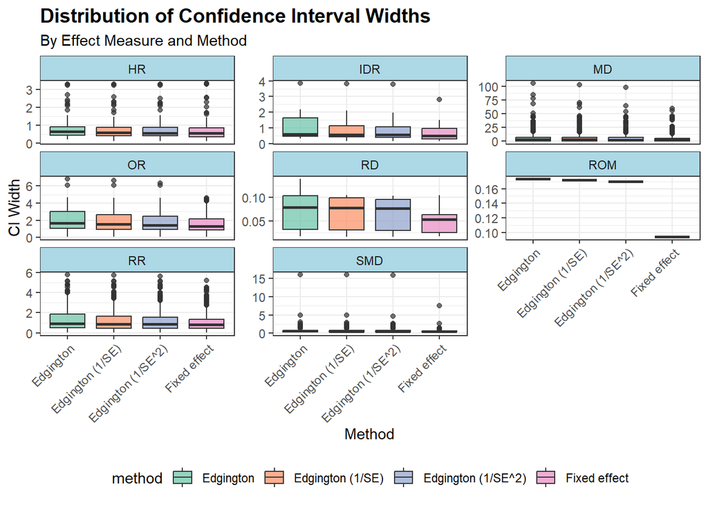

```r
widths_noHK <- widths %>%
  filter (method != "Hartung & Knapp")

ggplot(widths_noHK, aes(x = method, y = width, fill = method)) +
  geom_boxplot(alpha = 0.7) +
  facet_wrap(~ measure, scales = "free_y") +
  labs(
    title = "Distribution of Confidence Interval Widths",
    subtitle = "By Effect Measure and Method",
    x = "Method",
    y = "CI Width"
  ) +
  theme_bw() +
  theme(
    axis.text.x = element_text(angle = 45, hjust = 1),
    legend.position = "bottom",
    plot.title = element_text(face = "bold", size = 14),
    strip.background = element_rect(fill = "lightblue")
  ) +
  scale_fill_brewer(palette = "Set2")
```

## 2.2 Confidence interval skewness

The skewness of each confidence interval is computed as:

$$\text{Skewness} = \frac{\text{upper} + \text{lower} - 2 \times \text{estimate}}{\text{upper} - \text{lower}}$$

```r
ci_skewness <- extract_ma_metric(cis, "ci_skewness")

ci_skewness %>%
  filter(!method %in% c("Fixed effect", "Hartung & Knapp")) %>%
  group_by(method) %>%
  summarise(
    mean = mean(ci_skewness, na.rm = TRUE),
    median = median(ci_skewness, na.rm = TRUE),
    sd = sd(ci_skewness, na.rm = TRUE),
    q25 = quantile(ci_skewness, 0.25, na.rm = TRUE),
    q75 = quantile(ci_skewness, 0.75, na.rm = TRUE),
    min = min(ci_skewness, na.rm = TRUE),
    max = max(ci_skewness, na.rm = TRUE),
    .groups = "drop"
  ) %>%
  gt() %>%
  tab_header(
    title = md("**CI Skewness**"),
  ) %>%
  cols_label(
    method = "Method",
    mean = "Mean",
    median = "Median",
    sd = "SD",
    q25 = "Q25",
    q75 = "Q75",
    min = "Min",
    max = "Max"
  ) %>%
  fmt_number(
    columns = where(is.numeric),
    decimals = 3
  ) %>%
  cols_align(
    align = "center",
    columns = -method
  ) %>%
  tab_style(
    style = cell_text(weight = "bold"),
    locations = cells_column_labels()
  ) %>%
  opt_stylize(style = 6, color = "blue")
```

**CI Skewness**

| Method | Mean | Median | SD | Q25 | Q75 | Min | Max |
| --- | --- | --- | --- | --- | --- | --- | --- |
| Edgington | 0.003 | 0.000 | 0.186 | −0.054 | 0.052 | −0.853 | 0.892 |
| Edgington (1/SE) | −0.001 | 0.000 | 0.206 | −0.060 | 0.058 | −0.837 | 0.907 |
| Edgington (1/SE^2) | −0.005 | 0.000 | 0.170 | −0.055 | 0.050 | −0.770 | 0.765 |

## 2.3 Summary of Confidence Interval

How many individual study estimates fall outside their respective meta-analytic confidence intervals?

**Definitions:**

1. **Total Estimates:** The count of individual study estimates analyzed
2. **Outside CI (n):** Number of estimates falling outside the CI
3. **Outside CI (%):** Percentage of estimates falling outside the CI

```r
# Prepare data frames
ci_df <- bind_rows(
  lapply(cis, function(x) {
    x$ci %>%
      as.data.frame() %>%
      mutate(n_studies = nrow(x$inputs))
  }),
  .id = "MA"
)

est_df <- bind_rows(
  lapply(cis, function(x) {
    df <- as.data.frame(x$inputs)
    colnames(df)[1] <- "input_estimate"
    return(df)
  }),
  .id = "MA"
)

# Merge and calculate coverage
merged_df <- merge(est_df, ci_df, by = "MA") %>%
  mutate(
    outside_CI = input_estimate < lower | input_estimate > upper
  ) %>%
  rename(method_point_estimate = estimate)

# Calculate summary statistics
coverage_summary <- merged_df %>%
  group_by(method, n_studies) %>%
  summarise(
    n_estimates_total = n(),
    n_estimates_outside = sum(outside_CI, na.rm = TRUE),
    prop_outside = n_estimates_outside / n_estimates_total,
    .groups = "drop"
  )
```

```r
coverage_summary %>%
  select(-( n_studies)) %>%
  gt() %>%
  tab_header(
    title = md("**Confidence Interval Coverage Analysis**")
  ) %>%
  cols_label(
    method = "Method",
    n_estimates_total = "Total Estimates",
    n_estimates_outside = "Outside CI (n)",
    prop_outside = "Outside CI (%)"
  ) %>%
  fmt_number(
    columns = c(n_estimates_total, n_estimates_outside),
    decimals = 0,
    use_seps = TRUE
  ) %>%
  fmt_percent(
    columns = prop_outside,
    decimals = 1
  ) %>%
  cols_align(
    align = "center",
    columns = -method
  ) %>%
  data_color(
    columns = prop_outside,
    method = "numeric",
    palette = c("#ffffff", "#ffe5e5", "#ffcccc", "#ff9999"),
    domain = c(0, max(coverage_summary$prop_outside))
  ) %>%
  tab_style(
    style = cell_text(weight = "bold"),
    locations = cells_row_groups()
  ) %>%
  opt_stylize(style = 6, color = "blue")
```

Table 1

**Confidence Interval Coverage Analysis**

| Method | Total Estimates | Outside CI (n) | Outside CI (%) |
| --- | --- | --- | --- |
| Edgington | 2,330 | 0 | 0.0% |
| Edgington (1/SE) | 2,330 | 21 | 0.9% |
| Edgington (1/SE^2) | 2,330 | 90 | 3.9% |
| Fixed effect | 2,330 | 321 | 13.8% |
| Hartung & Knapp | 2,330 | 2 | 0.1% |

## 2.4 Number of significant meta-analyses

Proportion of significant *meta-analyses* by method (i.e. with intervals excluding 0).

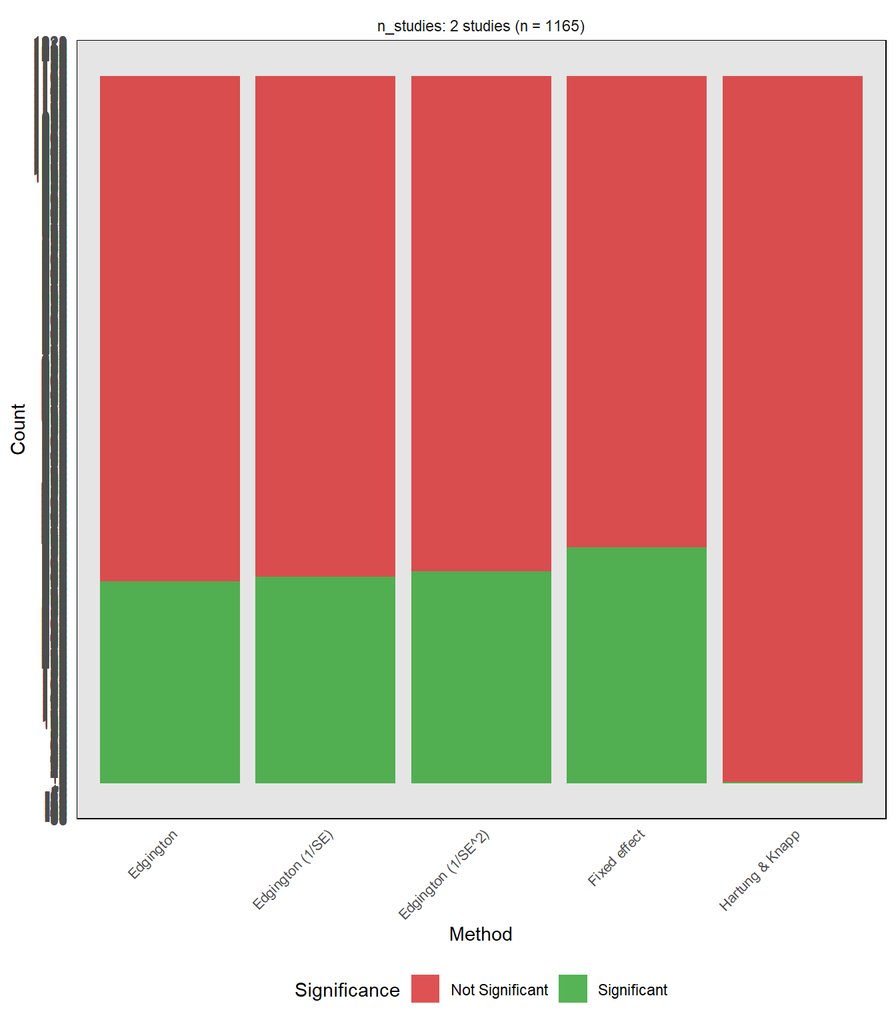

Figure 3

```r
sign <- extract_ma_metric(cis, "significant")

get_breaks <- function(limits) {
  seq(ceiling(min(limits)), floor(max(limits)), by = 1)
}

# Create plot
sign_plot <- sign %>%
  ggplot(aes(x = method, fill = significant)) +
  facet_wrap(~n_studies, scales = "free_y", labeller = label_both) +
  geom_bar(position = "stack", alpha = 0.8) +
  scale_y_continuous(breaks = get_breaks) +
  scale_fill_manual(
    values = c("TRUE" = "#2ca02c", "FALSE" = "#d62728"),
    labels = c("TRUE" = "Significant", "FALSE" = "Not Significant")
  ) +
  labs(
    x = "Method",
    y = "Count",
    fill = "Significance"
  ) +
  theme(
    axis.text.x = element_text(angle = 45, hjust = 1, size = 8),
    panel.grid.major = element_line(color = "grey90"),
    panel.border = element_rect(color = "black", fill = NA),
    plot.title = element_text(face = "bold", size = 12),
    legend.position = "bottom"
  )

sign_plot
```

```r
sign %>%
  group_by(method) %>%
  summarise(
    n_total = n(),
    n_significant = sum(significant == TRUE, na.rm = TRUE),
    prop_significant = n_significant / n_total,
    .groups = "drop"
  )  %>%
  gt() %>%
  tab_header(
    title = md("**Significance Statistics**"),
  ) %>%
  cols_label(
    method = "Method",
    n_total = "Total",
    n_significant = "Significant (n)",
    prop_significant = "Significant (%)"
  ) %>%
  fmt_number(
    columns = c(n_total, n_significant),
    decimals = 0
  ) %>%
  fmt_percent(
    columns = prop_significant,
    decimals = 1
  ) %>%
  cols_align(
    align = "center",
    columns = -method
  ) %>%
  data_color(
    columns = prop_significant,
    method = "numeric",
    palette = "Greens",
    domain = c(0, 1)
  ) %>%
  tab_style(
    style = cell_text(weight = "bold"),
    locations = cells_row_groups()
  ) %>%
  opt_stylize(style = 6, color = "blue")
```

Table 2

**Significance Statistics**

| Method | Total | Significant (n) | Significant (%) |
| --- | --- | --- | --- |
| Edgington | 1,165 | 332 | 28.5% |
| Edgington (1/SE) | 1,165 | 340 | 29.2% |
| Edgington (1/SE^2) | 1,165 | 349 | 30.0% |
| Fixed effect | 1,165 | 388 | 33.3% |
| Hartung & Knapp | 1,165 | 2 | 0.2% |

## 2.5 p-values (for $H_0: \theta=0$)

Distribution of method-specific p-values for testing $H_0: \theta=0$

*Note* the dashed line marks 0.05.

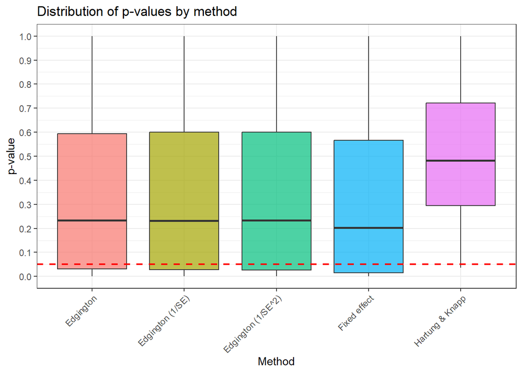

```r
pvals <- extract_ma_metric(cis, "p_0")


pvals %>%
  ggplot(aes(x = method, y = p_0, fill = method)) +
  geom_boxplot(alpha = 0.7, outlier.alpha = 0.3) +
  geom_hline(yintercept = 0.05, linetype = "dashed", color = "red", linewidth = 0.8) +
  scale_y_continuous(breaks = seq(0, 1, 0.1)) +
  labs(
    x = "Method",
    y = "p-value",
    title = "Distribution of p-values by method"
  ) +
  theme_bw() +
  theme(
    axis.text.x = element_text(angle = 45, hjust = 1),
    legend.position = "none"
  ) +
  coord_cartesian(ylim = c(0, 1))
```

```r
pvals %>%
  group_by(method) %>%
  summarise(
    mean = mean(p_0, na.rm = TRUE),
    median = median(p_0, na.rm = TRUE),
    sd = sd(p_0, na.rm = TRUE),
    q25 = quantile(p_0, 0.25, na.rm = TRUE),
    q75 = quantile(p_0, 0.75, na.rm = TRUE),
    min = min(p_0, na.rm = TRUE),
    max = max(p_0, na.rm = TRUE),
    .groups = "drop"
  ) %>%
  gt() %>%
  tab_header(
    title = md("**p-value Summary Statistics**")
  ) %>%
  cols_label(
    method = "Method",
    mean = "Mean",
    median = "Median",
    sd = "SD",
    q25 = "Q25",
    q75 = "Q75",
    min = "Min",
    max = "Max"
) %>%
  fmt_number(
    columns = c(mean, median, sd, q25, q75, min, max),
    decimals = 4
  )  %>%
  cols_align(
    align = "center",
    columns = -method
  ) %>%
  opt_stylize(style = 6, color = "blue")
```

Table 3

**p-value Summary Statistics**

| Method | Mean | Median | SD | Q25 | Q75 | Min | Max |
| --- | --- | --- | --- | --- | --- | --- | --- |
| Edgington | 0.3381 | 0.2333 | 0.3284 | 0.0309 | 0.5944 | 0.0000 | 1.0000 |
| Edgington (1/SE) | 0.3355 | 0.2311 | 0.3284 | 0.0282 | 0.6003 | 0.0000 | 1.0000 |
| Edgington (1/SE^2) | 0.3381 | 0.2329 | 0.3300 | 0.0271 | 0.6000 | 0.0000 | 1.0000 |
| Fixed effect | 0.3205 | 0.2023 | 0.3293 | 0.0159 | 0.5667 | 0.0000 | 1.0000 |
| Hartung & Knapp | 0.5143 | 0.4826 | 0.2636 | 0.2939 | 0.7211 | 0.0357 | 1.0000 |

### 2.5.1 Cumulative Distribution of P-values

In this graph the **ECDF** of p-values is plotted. The grey dashed line is the CDF of the Uniform distribution.

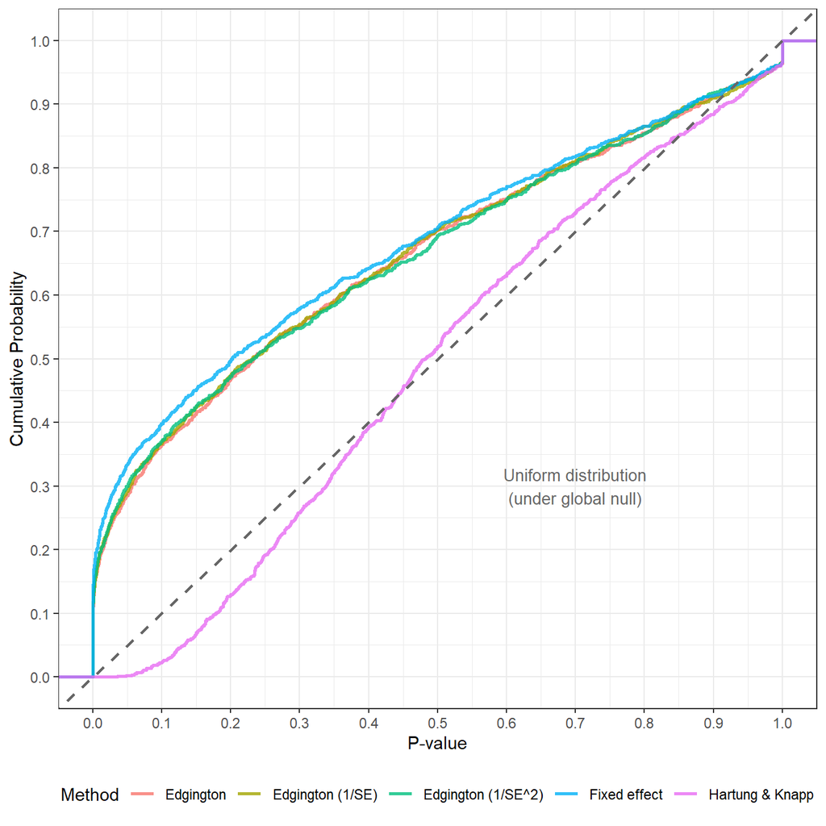

Figure 4

```r
pvals %>%
  ggplot(aes(x = p_0, color = method)) +
  stat_ecdf(geom = "step", linewidth = 1, alpha = 0.8) +
  geom_abline(intercept = 0, slope = 1, linetype = "dashed",
              color = "gray40", linewidth = 0.8) +
  annotate("text", x = 0.7, y = 0.3,
           label = "Uniform distribution\n(under global null)",
           color = "gray40", size = 3.5) +
  scale_x_continuous(breaks = seq(0, 1, 0.1)) +
  scale_y_continuous(breaks = seq(0, 1, 0.1)) +
  labs(
    x = "P-value",
    y = "Cumulative Probability",
    color = "Method"
    ) +
  theme_bw() +
  theme(
    legend.position = "bottom",
    legend.direction = "horizontal"
  ) +
  coord_cartesian(xlim = c(0, 1), ylim = c(0, 1))
```

### 2.5.2 P-value Comparison to Fixed Effect

Now, we will compare each method’s p-values with **Fixed Effect’s p-values as baseline.**

```r
pvals_wide <- pvals %>%
  select(MA, method, p_0) %>%
  pivot_wider(names_from = method, values_from = p_0)

# Calculate differences from Fixed Effect
only_fe <- pvals %>%
  filter(method == "Fixed effect") %>%
  select (MA, p_0_fe = p_0)

pvals_diff <- pvals %>%
  left_join(
    only_fe,
    by = "MA"
  ) %>%
  mutate (p_diff = p_0 - p_0_fe) %>%
  filter (method != "Fixed effect")
```

Here, each panel plots the FE p-values vs the p-value of the specific method.

*Note*: if the $p_0$ were equal, points would distribute on the diagonal.

**Each point is one meta-analysis.** Points below the diagonal indicate smaller p-values than fixed effect (less conservative), and points above indicate larger p-values (more conservative).

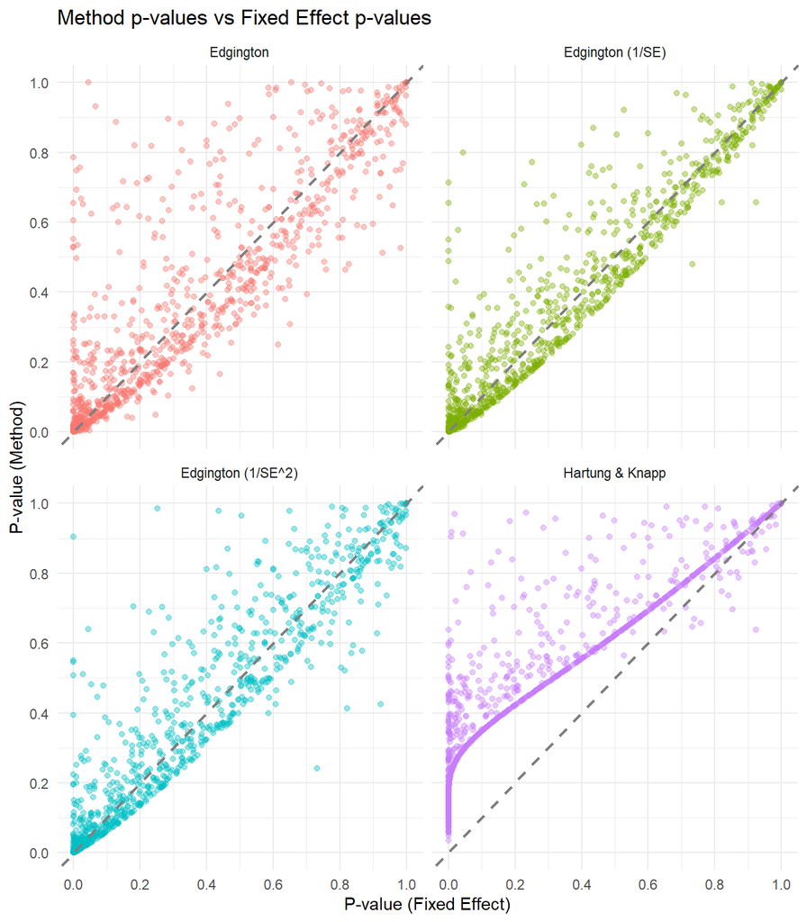

Figure 5

```r
pvals_diff %>%
  ggplot (aes(x = p_0_fe, y = p_0, color = method)) +
  geom_point(alpha= 0.4, size = 1.5) +
  geom_abline (intercept = 0, slope = 1, linetype = "dashed", color = "gray50", linewidth = 0.8) +
  facet_wrap (~method) +
  scale_x_continuous (breaks = seq(0,1, 0.2)) +
  scale_y_continuous(breaks = seq(0,1, 0.2)) +
  labs(
    x = "P-value (Fixed Effect)",
    y = "P-value (Method)",
    title = "Method p-values vs Fixed Effect p-values"
  ) +
  theme(
    legend.position = "none"
  )
```

### 2.5.3 P-value Differences from Fixed Effect

This table is similar to Table 3 but with a focus on the difference $\Delta p = p_0 (method) - p_0 (FE)$ and showing the correlation between $p_0(method)$ and $p_0 (FE)$ .

```r
pvals_diff %>%
  group_by(method) %>%
  summarise(
    mean_diff = mean(p_diff, na.rm = TRUE),
    median_diff = median(p_diff, na.rm = TRUE),
    sd_diff = sd(p_diff, na.rm = TRUE),
    cor_with_fe = cor(p_0, p_0_fe, use = "complete.obs"),
    .groups = "drop"
  ) %>%
  gt() %>%
  tab_header(
    title = md("**P-value Differences from Fixed Effect**")
  ) %>%
  cols_label(
    method = "Method",
    mean_diff = "Mean Δ",
    median_diff = "Median Δ",
    sd_diff = "SD Δ",
    cor_with_fe = "Correlation"
  ) %>%
  fmt_number(
    columns = c(mean_diff, median_diff, sd_diff, cor_with_fe),
    decimals = 4
  ) %>%
  cols_align(
    align = "center",
    columns = -method
  ) %>%
  opt_stylize(style = 6, color = "blue")
```

Table 4

**P-value Differences from Fixed Effect**

| Method | Mean Δ | Median Δ | SD Δ | Correlation |
| --- | --- | --- | --- | --- |
| Edgington | 0.0175 | 0.0000 | 0.1496 | 0.8966 |
| Edgington (1/SE) | 0.0150 | 0.0000 | 0.0944 | 0.9588 |
| Edgington (1/SE^2) | 0.0176 | 0.0000 | 0.1075 | 0.9468 |
| Hartung & Knapp | 0.1938 | 0.1930 | 0.1397 | 0.9125 |

### 2.5.4 Agreement in Significance (p < 0.05)

Here we inspect the significance agreement between the values

Each meta-analysis is classified into **four categories:** both significant, both non-significant, FE-only, or method-only.

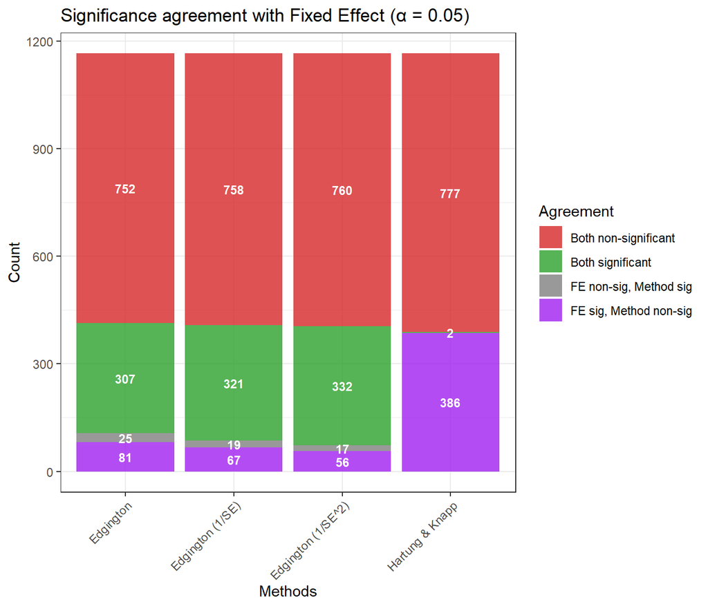

Figure 6

```r
sign_agree_p <- pvals_diff %>%
  group_by(method) %>%
  mutate (
    Method_sign = p_0 <0.05,
    FE_sign = p_0_fe <0.05,
    agreement = ifelse(FE_sign & Method_sign, "Both significant",
                       ifelse(!FE_sign & !Method_sign, "Both non-significant",
                              ifelse(FE_sign & !Method_sign, "FE sig, Method non-sig",
                                     "FE non-sig, Method sig"))))






sign_agree_p %>%
  count(method, agreement) %>%
  ggplot(aes(x = method, y = n, fill = agreement)) +
           geom_col (position= "stack", alpha = 0.8) +
  geom_text(aes(label = n), position = position_stack(vjust = 0.5), size = 3,
            color = "white", fontface = "bold") +
  scale_fill_manual (
    values = c(      "Both significant" = "#2ca02c",
                     "Both non-significant" = "#d62728",
                     "FE sig, Method non-sig" = "purple",
                     "FE non-sig, Method sig" = "#7f7f7f"
    )) +
  labs (
    x = "Methods",
    y = "Count",
    fill = "Agreement",
    title = "Significance agreement with Fixed Effect (α = 0.05)"
  ) +
  theme_bw() +
  theme(
    axis.text.x = element_text(angle = 45, hjust = 1),
    legend.position = "right"
  )
```

```r
sign_agree_p %>%
  group_by(method) %>%
  summarise(
    n_total = n(),
    both_sig = sum(FE_sign & Method_sign, na.rm = TRUE),
    both_nonsig = sum(!FE_sign & !Method_sign, na.rm = TRUE),
    fe_only = sum(FE_sign & !Method_sign, na.rm = TRUE),
    method_only = sum(!FE_sign & Method_sign, na.rm = TRUE),
    .groups = "drop"
  ) %>%
  gt() %>%
  tab_header(
    title = md("**Significance Agreement with Fixed Effect**")
  ) %>%
  cols_label(
    method = "Method",
    n_total = "Total",
    both_sig = "Both Sig",
    both_nonsig = "Both Non-sig",
    fe_only = "FE Only",
    method_only = "Method Only",
  ) %>%
  fmt_number(
    columns = c(n_total, both_sig, both_nonsig, fe_only, method_only),
    decimals = 0
  ) %>%
  cols_align(
    align = "center",
    columns = -method
  )  %>%
  opt_stylize(style = 6, color = "blue")
```

Table 5

**Significance Agreement with Fixed Effect**

| Method | Total | Both Sig | Both Non-sig | FE Only | Method Only |
| --- | --- | --- | --- | --- | --- |
| Edgington | 1,165 | 307 | 752 | 81 | 25 |
| Edgington (1/SE) | 1,165 | 321 | 758 | 67 | 19 |
| Edgington (1/SE^2) | 1,165 | 332 | 760 | 56 | 17 |
| Hartung & Knapp | 1,165 | 2 | 777 | 386 | 0 |

## 2.6 Coherence of skewness signs (β, γ, AUCC ratio)

Agreement between different measures of skewness:

- **β (beta)**: CI skewness
- **γ (gamma)**: Data skewness
- **AUCC ratio**: Area Under Confidence Curve ratio

where
$$\gamma = \frac{\sum_{i=1}^{n} w_i (\hat{\theta} - \bar{\theta})^3}{\left( \sum_{i=1}^{n} w_i (\hat{\theta} - \bar{\theta})^2 \right)^{3/2} / \sqrt{\sum_{i=1}^{n} w_i}}$$
is Fisher’s weighted skewness coefficient.

And
$$\text{AUCC Ratio} = \frac {\text{AUCC}_{\text{upper}} - \text{AUCC}_{\text{lower}}} {AUCC}$$
.

*For more details see: Held, Leonhard, Felix Hofmann, and Samuel Pawel. “A comparison of combined p-value functions for meta-analysis.” Research Synthesis Methods (2025)*

```r
# Build sign agreement dataset
sign_agreement <- do.call(rbind, lapply(cis, function(x) {
  df <- x$ci
  df <- subset(df, !is.na(ci_skewness) & !method %in% c("Fixed effect", "Hartung & Knapp", "Bayesmeta"))
  data.frame(
    MA = x$ma_id,
    method = df$method,
    data_skewness = x$data_skewness,
    ci_skewness = df$ci_skewness,
    aucc_ratio = df$aucc_ratio
  )
})) %>%
  mutate(
    same_sign_beta_gamma = sign(data_skewness) == sign(ci_skewness),
    same_sign_beta_aucc = sign(ci_skewness) == sign(aucc_ratio),
    same_sign_gamma_aucc = sign(data_skewness) == sign(aucc_ratio)
  )
```

```r
# Calculate summary statistics
sign_summary <- sign_agreement %>%
  group_by(method) %>%
  summarise(
    n_MA = n(),
    agree_beta_gamma = sum(same_sign_beta_gamma, na.rm = TRUE),
    agree_beta_aucc = sum(same_sign_beta_aucc, na.rm = TRUE),
    agree_gamma_aucc = sum(same_sign_gamma_aucc, na.rm = TRUE),
    corr_beta_gamma = cor(ci_skewness, data_skewness, use = "complete.obs"),
    corr_beta_aucc = cor(ci_skewness, aucc_ratio, use = "complete.obs"),
    corr_gamma_aucc = cor(data_skewness, aucc_ratio, use = "complete.obs"),
    .groups = "drop"
  )

# Create gt table
sign_summary %>%
  gt() %>%
  tab_header(
    title = md("**Sign Agreement**"),
  ) %>%
  tab_spanner(
    label = md("**Sign Agreement (Count)**"),
    columns = c(agree_beta_gamma, agree_beta_aucc, agree_gamma_aucc)
  ) %>%
  tab_spanner(
    label = md("**Pearson Correlation**"),
    columns = c(corr_beta_gamma, corr_beta_aucc, corr_gamma_aucc)
  ) %>%
  cols_label(
    method = "Method",
    n_MA = md("*MA*"),
    agree_beta_gamma = "β vs γ",
    agree_beta_aucc = "β vs AUCC",
    agree_gamma_aucc = "γ vs AUCC",
    corr_beta_gamma = "β vs γ",
    corr_beta_aucc = "β vs AUCC",
    corr_gamma_aucc = "γ vs AUCC"
  ) %>%
  fmt_number(
    columns = starts_with("corr"),
    decimals = 3
  ) %>%
  fmt_number(
    columns = c(n_MA, starts_with("agree")),
    decimals = 0
  ) %>%
  sub_missing(
    columns = everything(),
    missing_text = "–"
  ) %>%
  cols_align(
    align = "center",
    columns = -method
  ) %>%
  tab_style(
    style = cell_text(weight = "bold"),
    locations = cells_column_labels()
  ) %>%
  opt_stylize(style = 6, color = "blue")
```

Table 6

**Sign Agreement**

| Method | *MA* | **Sign Agreement (Count)** β vs γ | **Sign Agreement (Count)** β vs AUCC | **Sign Agreement (Count)** γ vs AUCC | **Pearson Correlation** β vs γ | **Pearson Correlation** β vs AUCC | **Pearson Correlation** γ vs AUCC |
| --- | --- | --- | --- | --- | --- | --- | --- |
| Edgington | 1,165 | 1,104 | 1,125 | 1,094 | 0.655 | 0.990 | 0.669 |
| Edgington (1/SE) | 1,165 | 1,103 | 1,135 | 1,102 | 0.455 | 0.971 | 0.423 |
| Edgington (1/SE^2) | 1,165 | 1,106 | 1,135 | 1,104 | 0.277 | 0.969 | 0.252 |

## 2.7 Sign agreement among β, γ, and AUCC ratio

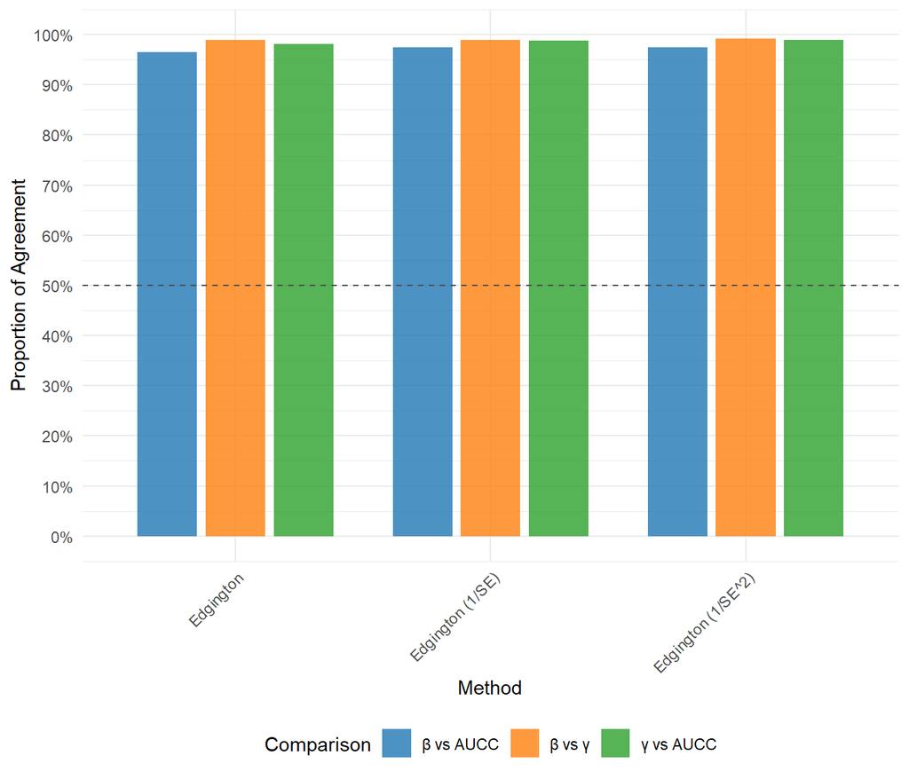

Figure 7

```r
sign_long <- sign_agreement %>%
  filter(!method %in% c("Fixed effect", "Hartung & Knapp")) %>%
  select(MA, method, starts_with("same_sign")) %>%
  pivot_longer(
    cols = starts_with("same_sign"),
    names_to = "comparison",
    values_to = "agreement"
  ) %>%
  filter(!is.na(agreement))

# Create bar plot showing proportions
sign_long %>%
  mutate(
    comparison = case_when(
      comparison == "same_sign_beta_gamma" ~ "β vs γ",
      comparison == "same_sign_beta_aucc" ~ "β vs AUCC",
      comparison == "same_sign_gamma_aucc" ~ "γ vs AUCC"
    )
  ) %>%
  group_by(method, comparison) %>%
  summarise(
    prop_agree = mean(agreement, na.rm = TRUE),
    .groups = "drop"
  ) %>%
  ggplot(aes(x = method, y = prop_agree, fill = comparison)) +
  geom_col(position = position_dodge(0.8), width = 0.7, alpha = 0.8) +
  geom_hline(yintercept = 0.5, linetype = "dashed", color = "grey30") +
  scale_y_continuous(
    labels = scales::percent_format(),
    limits = c(0, 1),
    breaks = seq(0, 1, 0.1)
  ) +
  scale_fill_manual(
    values = c("#1f77b4", "#ff7f0e", "#2ca02c")
  ) +
  labs(
    x = "Method",
    y = "Proportion of Agreement",
    fill = "Comparison"
  ) +
  theme_minimal() +
  theme(
    axis.text.x = element_text(angle = 45, hjust = 1),
    plot.title = element_text(face = "bold", size = 12),
    legend.position = "bottom"
  )
```

## 2.8 Lemma 4.3.1

**Lemma 4.3.1 (Two-study case)**

Consider a meta-analysis with exactly two studies, with point estimates $\hat\theta_1, \hat\theta_2$ and standard errors $\sigma_1, \sigma_2 > 0$. Let the confidence level be $1-\alpha$ with $0 < \alpha < 1/4$, and define:

$$z_{\alpha/2} := \Phi^{-1}(\alpha/2), \qquad z_{\sqrt{\alpha/4}} := \Phi^{-1}\!\left(\sqrt{\alpha/4}\right)$$

where $\Phi^{-1}$ denotes the quantile function of the standard normal distribution. Let $\text{width}_E$ be the width of the $(1-\alpha)$-confidence interval based on the unweighted Edgington method, and $\text{width}_{FE}$ the width of the fixed-effect confidence interval.

Set $\Delta\theta := |\hat\theta_1 - \hat\theta_2|$. If at least one of the following two conditions holds, then $\text{width}_E < \text{width}_{FE}$.

**Condition 1:**
$$\frac{\max(\sigma_1,\sigma_2)}{\min(\sigma_1,\sigma_2)} \;<\; \sqrt{\left(\frac{z_{\alpha/2}}{z_{\sqrt{\alpha/4}}}\right)^2 - 1}$$
and
$$\Delta\theta \;<\; -\,z_{\sqrt{\alpha/4}}\,\big|\sigma_2 - \sigma_1\big|$$

**Condition 2:**
$$-\,z_{\sqrt{\alpha/4}}\,\big|\sigma_2 - \sigma_1\big| \;\le\; \Delta\theta \;<\; \frac{\sigma_1 \sigma_2}{\sqrt{\sigma_1^2 + \sigma_2^2}}\, \big(-2 z_{\alpha/2}\big) \;+\; (\sigma_1 + \sigma_2)\,z_{\sqrt{\alpha/4}}$$

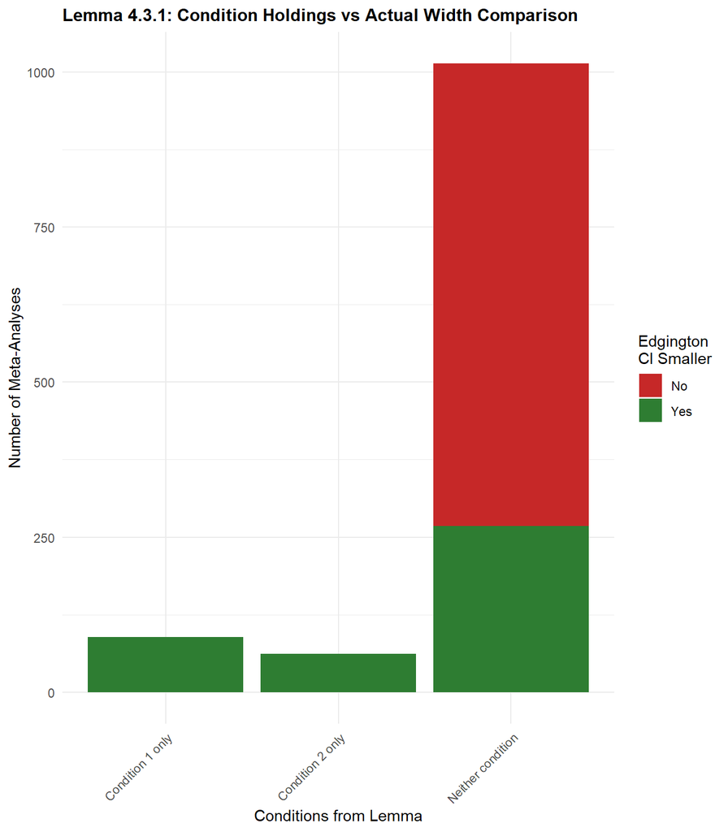

Figure 8

```r
alpha <- 0.05

# Check lemma conditions
cis_lemma <- check_lemma_conditions(cis, alpha = alpha)

# Extract and summarize results
lemma_detailed <- extract_lemma_results(cis_lemma)


lemma_applicable <- lemma_detailed %>%
  filter(applicable == TRUE)

# Plot results
plot_lemma_results(cis_lemma)
```

```r
# Create simple summary table
lemma_summary <- lemma_applicable %>%
  summarise(
    "Total 2-Study MAs" = n(),
    "Condition 1 Holds" = sum(condition1_holds, na.rm = TRUE),
    "Condition 2 Holds" = sum(condition2_holds, na.rm = TRUE),
    "Both Conditions" = sum(condition1_holds & condition2_holds, na.rm = TRUE),
    "Neither Condition" = sum(!condition1_holds & !condition2_holds, na.rm = TRUE),
    "Edgington < FE" = sum(edgington_smaller, na.rm = TRUE),
    "Lemma Verified" = sum(lemma_verified == TRUE, na.rm = TRUE),
    "Lemma Failed" = sum(lemma_verified == FALSE, na.rm = TRUE)
  ) %>%
  pivot_longer(
    everything(),
    names_to = "Metric",
    values_to = "Count"
  ) %>%
  mutate(
    Percentage = ifelse(
      Metric == "Total 2-Study MAs",
      NA_real_,
      Count / first(Count) * 100
    )
  )

# Create table
lemma_summary %>%
  gt() %>%
  tab_header(
    title = md("**Lemma 4.3.1 Summary Statistics**"),
  ) %>%
  fmt_number(
    columns = Count,
    decimals = 0,
    use_seps = TRUE
  ) %>%
  fmt_number(
    columns = Percentage,
    decimals = 1,
    suffix = "%"
  ) %>%
  sub_missing(
    columns = Percentage,
    missing_text = "—"
  ) %>%
  cols_align(
    align = "left",
    columns = Metric
  ) %>%
  cols_align(
    align = "center",
    columns = c(Count, Percentage)
  ) %>%
  tab_style(
    style = cell_text(weight = "bold"),
    locations = cells_body(rows = Metric == "Total 2-Study MAs")
  ) %>%
  tab_style(
    style = cell_fill(color = "#f0f0f0"),
    locations = cells_body(rows = Metric == "Total 2-Study MAs")
  ) %>%
  opt_stylize(style = 6, color = "blue")
```

Table 7

**Lemma 4.3.1 Summary Statistics**

| Metric | Count | Percentage |
| --- | --- | --- |
| Total 2-Study MAs | 1,165 | — |
| Condition 1 Holds | 89 | 7.6 |
| Condition 2 Holds | 62 | 5.3 |
| Both Conditions | 0 | 0.0 |
| Neither Condition | 1,014 | 87.0 |
| Edgington < FE | 419 | 36.0 |
| Lemma Verified | 151 | 13.0 |
| Lemma Failed | 0 | 0.0 |

# 3 Checking Estimates

Inspecting the Estimates (which are the point which has the highest p-value) provided by each method

```r
estimates_df <- extract_ma_metric(cis, "estimates")

# Calculate summary statistics
estimate_summary <- estimates_df %>%
  group_by(method) %>%
  summarise(
    mean = mean(estimates, na.rm = TRUE),
    sd = sd(estimates, na.rm = TRUE),
    median = median(estimates, na.rm = TRUE),
    q25 = quantile(estimates, 0.25, na.rm = TRUE),
    q75 = quantile(estimates, 0.75, na.rm = TRUE),
    min = min(estimates, na.rm = TRUE),
    max = max(estimates, na.rm = TRUE),
    .groups = "drop"
  )


estimate_summary %>%
  gt() %>%
  tab_header(
    title = md("**Meta Analytic estimates**"),
  ) %>%
  cols_label(
    method = "Method",
    mean = "Mean",
    sd = "SD",
    median = "Median",
    q25 = "Q25",
    q75 = "Q75",
    min = "Min",
    max = "Max"
  ) %>%
  fmt_number(
    columns = c(sd, median, q25, q75, min, max),
    decimals = 2
  ) %>%
    fmt_number(
    columns = c(mean),
    decimals = 4
  ) %>%
  cols_align(
    align = "center",
    columns = -method
  ) %>%
  tab_style(
    style = cell_text(weight = "bold"),
    locations = cells_column_labels()
  ) %>%
  opt_stylize(style = 6, color = "blue")
```

**Meta Analytic estimates**

| Method | Mean | SD | Median | Q25 | Q75 | Min | Max |
| --- | --- | --- | --- | --- | --- | --- | --- |
| Edgington | −0.0925 | 3.52 | 0.00 | −0.30 | 0.33 | −43.03 | 40.16 |
| Edgington (1/SE) | −0.0690 | 3.68 | 0.00 | −0.28 | 0.32 | −46.61 | 52.49 |
| Edgington (1/SE^2) | −0.0567 | 3.79 | 0.00 | −0.27 | 0.30 | −47.22 | 58.31 |
| Fixed effect | −0.0735 | 3.58 | 0.00 | −0.28 | 0.31 | −44.56 | 47.95 |
| Hartung & Knapp | −0.1042 | 3.73 | 0.00 | −0.29 | 0.31 | −49.16 | 40.79 |

Here, delta(Δ) = designated method - Fixed effect

```r
# wide: one row per MA, one column per method
wide_estimates <- estimates_df %>%
  select(MA, method, estimates) %>%
  pivot_wider(names_from = method, values_from = estimates)

# long comparison vs FE
long_vs_FE <- wide_estimates %>%
  pivot_longer(
    cols = -c(MA, `Fixed effect`),#keep FE as column so that I can compare
    names_to = "method",
    values_to = "method_est"
  ) %>%
  mutate(
    fe = `Fixed effect`,
    delta = method_est - fe,
    method_bigger_FE = method_est > `Fixed effect`,
    method_smaller_FE = method_est < `Fixed effect`,
    equal = method_est == `Fixed effect`
  ) %>%
  select (-`Fixed effect`)



# summary table
summary_vs_FE <- long_vs_FE %>%
  group_by(method) %>%
  summarise(
    n = n(),
    pct_method_bigger_FE = mean(method_bigger_FE) * 100,
    pct_method_smaller_FE = mean(method_smaller_FE) * 100,
    pct_equal = mean(equal) * 100,
    mean_delta = mean(delta),
    mean_abs_delta = mean(abs(delta)),
    .groups = "drop"
  )


summary_vs_FE %>%
  gt() %>%
  tab_header(
    title = md("**Meta Analytic delta-estimates**"),
  ) %>%
  cols_label(
    method = "Method",
    n = "N studies",
    pct_method_bigger_FE = "Bigger than FE (%)",
    pct_method_smaller_FE = "Smaller than FE (%)",
    pct_equal = "Equal (%)",
    mean_delta = "Mean Δ",
    mean_abs_delta = "Mean Abs Δ"
  ) %>%
  fmt_number(
    columns = c(pct_method_bigger_FE, pct_method_smaller_FE),
    decimals = 2
  ) %>%
    fmt_number(
    columns = c(mean_delta, mean_abs_delta),
    decimals = 4
  ) %>%
  cols_align(
    align = "center",
    columns = -method
  ) %>%
  tab_style(
    style = cell_text(weight = "bold"),
    locations = cells_column_labels()
  ) %>%
  opt_stylize(style = 6, color = "blue")
```

**Meta Analytic delta-estimates**

| Method | N studies | Bigger than FE (%) | Smaller than FE (%) | Equal (%) | Mean Δ | Mean Abs Δ |
| --- | --- | --- | --- | --- | --- | --- |
| Edgington | 1165 | 46.87 | 48.93 | 4.206009 | −0.0190 | 0.0946 |
| Edgington (1/SE) | 1165 | 49.36 | 46.44 | 4.206009 | 0.0045 | 0.0402 |
| Edgington (1/SE^2) | 1165 | 48.84 | 46.95 | 4.206009 | 0.0168 | 0.1038 |
| Hartung & Knapp | 1165 | 41.89 | 43.69 | 14.420601 | −0.0307 | 0.1224 |

```r
#COMMENTED OUT:
# Not sure if we want to inspect those studies where we have the same meta analytic estimate

#same_estimate <- wide_estimates %>%
#  filter (Edgington == `Fixed effect`)

#list <- same_estimate$MA


#un <- unlist(list)
#same_est <- cis[un]

#extract only inputs from each elemnt of the list
#lapply(same_est, "[[" , "inputs")
```

## 3.1 Agreement of sign of Estimates

Comparison of the **direction** of each method’s estimate with the **Fixed Effect** one.

For each method, we summarise:

The proportion of meta-analyses for which at least one of the FE or method estimates has no well-defined sign (|estimate| ≤ tol).

The proportion of meta-analyses where the method has the same sign as FE and the proportion with a flipped sign relative to FE, **among all meta-analyses**

```r
# Sign treshold ->  If a value is smaller than this, it is not considered as a sign. VALUE CAN BE CHANGED
tol <- 1e-6

#Better sign function w tolerance
sign3 <- function(x, tol) {
       ifelse(abs(x) <= tol, 0L, ifelse(x > 0, 1L, -1L))
}

long_vs_FE <- long_vs_FE %>%
  mutate(
    sign_fe = sign3(fe, tol),
    sign_method = sign3(method_est, tol),
    sign_defined = (sign_fe != 0L) & (sign_method != 0L), #both different from 0
    sign_agree = ifelse(sign_defined, sign_fe == sign_method, NA), # same sign, if sign not defined put NA
    sign_flip = ifelse(sign_defined, sign_fe != sign_method, NA),
  )




summ_long_vs_FE <- long_vs_FE %>%
  group_by(method) %>%
  summarise(
    n_total = n(),
    prop_sign_non.defined = mean(!sign_defined, na.rm = TRUE) *100,
    prop_same_sign = sum(sign_agree, na.rm = TRUE) / n_total *100,
    prop_flip_sign = sum(sign_flip, na.rm = TRUE) / n_total * 100,
    .groups = "drop"
  )


summ_long_vs_FE %>%
  gt() %>%
  tab_header(
    title = md("**Agreement of sign with Fixed Effect**")
  ) %>%
  cols_label(
    method = "Method",
    n_total = "N studies",
    prop_sign_non.defined = "Sign not defined (%)",
    prop_same_sign = "Same sign as FE (%)",
    prop_flip_sign = "Sign flip vs FE (%)",
  ) %>%
  fmt_number(
    columns = c(prop_sign_non.defined, prop_same_sign, prop_flip_sign),
    decimals = 2
  ) %>%
  fmt_number(
    columns = c(n_total),
    decimals = 0,
    use_seps = TRUE
  ) %>%
  cols_align(
    align = "center",
    columns = -method
  ) %>%
  tab_style(
    style = cell_text(weight = "bold"),
    locations = cells_column_labels()
  ) %>%
  opt_stylize(style = 6, color = "blue")
```

**Agreement of sign with Fixed Effect**

| Method | N studies | Sign not defined (%) | Same sign as FE (%) | Sign flip vs FE (%) |
| --- | --- | --- | --- | --- |
| Edgington | 1,165 | 3.43 | 93.56 | 3.00 |
| Edgington (1/SE) | 1,165 | 3.43 | 96.14 | 0.43 |
| Edgington (1/SE^2) | 1,165 | 3.43 | 93.39 | 3.18 |
| Hartung & Knapp | 1,165 | 3.43 | 94.16 | 2.40 |

## 3.2 Shrinkage ratio

$SR = \frac {\hat{\mu}_{\text{method}}} {\hat{\mu}_{\text{FE}}}$

Negative values of SR indicate a **sign flip** relative to FE, while positive values indicate agreement in direction. Among positive ratios, values between 0 and 1 correspond to **shrinkage toward zero** relative to FE, and values larger than 1 indicate **more extreme estimates** than FE. Finally, value equal to 1 indicate that the two methods provide the same estimate.

For each method, we report how often estimates flip sign, how often they are shrunken toward zero, how often they are more extreme than FE.

```r
# ---- SHRINKAGE RATIO SR = method / FE ----

ratio_df <- long_vs_FE %>%
  mutate(
    SR = method_est / fe,                     #  shrinkage ratio
    SR_class = case_when(
      SR < 0 ~ "Flip sign (SR<0)",
      SR >= 0 & SR < 1 ~ "Shrink toward 0 (0<=SR<1)",
      SR == 1 ~ "Equal (SR=1)",
      SR > 1 ~ "More extreme (SR>1)"
      )
  )

ratio_summary <- ratio_df %>%
  group_by(method) %>%
  summarise(
    n = n(),
    prop_flip = mean(SR < 0, na.rm = TRUE) *100,
    prop_shrink = mean(SR >= 0 & SR < 1, na.rm = TRUE) *100,
    prop_more_extreme = mean(SR > 1, na.rm = TRUE) * 100,
    prop_exactly_same = mean(SR == 1, na.rm = TRUE) * 100,
    .groups = "drop"
  )

ratio_summary %>%
  gt() %>%
  tab_header(
    title = md("**Shrinkage ratio summary**"),
  ) %>%
  cols_label(
    method = "Method",
    n = "N studies",
    prop_flip = "Flipped signs (%)",
    prop_shrink = "Shrinked estimates(%)",
    prop_more_extreme = "More extreme estimates (%)",
    prop_exactly_same = "Exactly same estimates (%)"
    ) %>%
  fmt_number(
    columns = c(prop_flip, prop_shrink, prop_more_extreme, prop_exactly_same),
    decimals = 2
  ) %>%
  cols_align(
    align = "center",
    columns = -method
  ) %>%
  tab_style(
    style = cell_text(weight = "bold"),
    locations = cells_column_labels()
  ) %>%
  opt_stylize(style = 6, color = "blue")
```

**Shrinkage ratio summary**

| Method | N studies | Flipped signs (%) | Shrinked estimates(%) | More extreme estimates (%) | Exactly same estimates (%) |
| --- | --- | --- | --- | --- | --- |
| Edgington | 1165 | 3.11 | 43.91 | 52.18 | 0.80 |
| Edgington (1/SE) | 1165 | 0.44 | 52.09 | 46.67 | 0.80 |
| Edgington (1/SE^2) | 1165 | 3.29 | 48.36 | 47.56 | 0.80 |
| Hartung & Knapp | 1165 | 2.49 | 37.87 | 48.27 | 11.38 |